# TOD Areas Are Gaining Attention: The Perfect Time for Developers to Invest

By LUMING XU

2024-09-24 (A draft version)

```r
# Load packages and functions

library(tidyverse)
library(tidycensus)
library(sf)
library(kableExtra)
library(gridExtra)
library(cowplot)
library(geosphere)
library(dplyr)

options(scipen=999) # a penalty for printing scientific notation
options(tigris_class = "sf") # tells the tigris package to return spatial data as an sf object

source("https://raw.githubusercontent.com/urbanSpatial/Public-Policy-Analytics-Landing/master/functions.r")

palette5 <- c("#f0f9e8","#bae4bc","#7bccc4","#43a2ca","#0868ac")
```

```r
# Load API
census_api_key("e62580f74ef222beadd9dd2fbaf48ff130b31c4a", overwrite = TRUE)
```

```r
# Spatial intersection with `st_centroid()` on polygon centroids
# 2012
selectCentroids.12 <-
  st_centroid(tracts12)[buffer,] %>%
  st_drop_geometry() %>%
  left_join(., dplyr::select(tracts22, GEOID), by = "GEOID") %>%
  st_sf() %>%
  dplyr::select(TotalPop) %>%
  mutate(Selection_Type = "Select by Centroids_2012")
# 2022
selectCentroids.22 <-
  st_centroid(tracts22)[buffer,] %>%
  st_drop_geometry() %>%
  left_join(., dplyr::select(tracts22, GEOID), by = "GEOID") %>%
  st_sf() %>%
  dplyr::select(TotalPop) %>%
  mutate(Selection_Type = "Select by Centroids_2022")
```

```r
allTracts.group <-
  rbind(
    st_centroid(allTracts)[buffer,] %>%
      st_drop_geometry() %>%
      left_join(allTracts) %>%
      st_sf() %>%
      mutate(TOD = "TOD"),
    st_centroid(allTracts)[buffer, op = st_disjoint] %>%
      st_drop_geometry() %>%
      left_join(allTracts) %>%
      st_sf() %>%
      mutate(TOD = "Non-TOD")) %>%
  mutate(MedRent.inf = ifelse(year == "2012", MedRent * 1.24, MedRent))
```

```r
# Compute MRB
muni_MRB <- multipleRingBuffer(st_union(Muni_Metro),
                                maxDistance = 18480,
                                interval =  2640)
```

```r
# Summarizing data
# 2012 data
tracts12.rings <- tracts12 %>%
  select(GEOID, year) %>%
  st_centroid() %>%
  st_join(muni_MRB, join = st_intersects) %>%
  st_drop_geometry() %>%
  left_join(dplyr::select(tracts12, GEOID, MedRent, year),
            by=c("GEOID"="GEOID", "year"="year")) %>%
  st_sf() %>%
  mutate(distance = distance / 5280) #convert to miles

tracts12.rings.summary <- st_drop_geometry(tracts12.rings) %>%
    group_by(distance, year) %>%
    summarize(Mean_Rent = mean(MedRent, na.rm=T))
# 2022 data
tracts22.rings <- tracts22 %>%
  select(GEOID, year) %>%
  st_centroid() %>%
  st_join(muni_MRB, join = st_intersects) %>%
  st_drop_geometry() %>%
  left_join(dplyr::select(tracts22, GEOID, MedRent, year),
            by=c("GEOID"="GEOID", "year"="year")) %>%
  st_sf() %>%
  mutate(distance = distance / 5280) #convert to miles

tracts22.rings.summary <- st_drop_geometry(tracts22.rings) %>%
    group_by(distance, year) %>%
    summarize(Mean_Rent = mean(MedRent, na.rm=T))

# combine data
tracts.rings.summary <- rbind(tracts12.rings.summary, tracts22.rings.summary)
```

The low rent of TOD areas in San Francisco provides best opportunities for developers to get into the field.

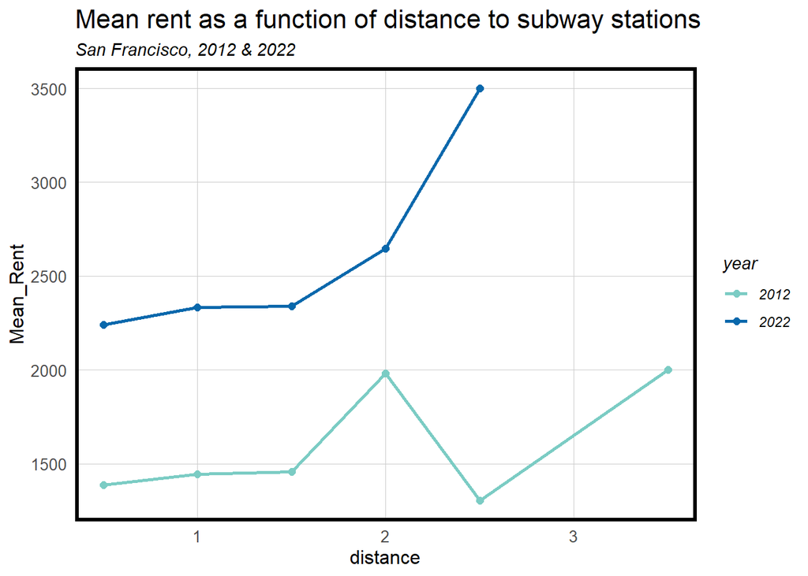

```r
# plot
ggplot(tracts.rings.summary,
       aes(distance, Mean_Rent, colour=year)) +
      geom_point(size=2) +
  geom_line(size=1) +
  scale_color_manual(values = c("#7bccc4", "#0868ac"))+
  labs(title = "Mean rent as a function of distance to subway stations",
       subtitle = "San Francisco, 2012 & 2022") +
  plotTheme()
```

# Background of the Story

- WE: a data analysis firm
- CLIENT: a developer
- AIM: TOD lands in San Francisco are available to develop - help our client evaluate whether to invest
- BIG IDEA: best time for the developer to invest in TOD for apartments since the decreasing gap in rent and income

# Now My Story Begins!

The Car ownership statistics 2024 reports that 82% of people in the United States own a vehicle in 2024. Car ownership of households rise from 87.1% to 91.7% from 2018 to 2022, showing a constant growing trend.

When car ownership tend to increase further, is the TOD area a wise choice for our developer to gain long-term benefits? Or waiting for an opportunity to develop new districts far from railway stations is better?

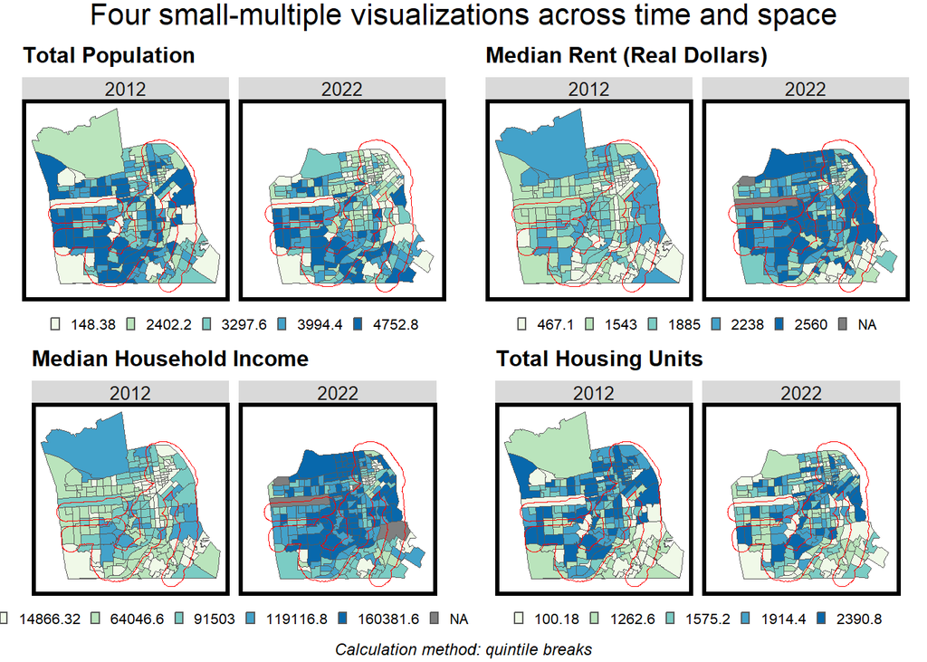

```r
create_plot <- function(data, aes_fill, label) {
  ggplot(data) +
    geom_sf(data = st_union(tracts22)) +
    geom_sf(aes(fill = q5(.data[[aes_fill]]))) +
    geom_sf(data = buffer, fill = "transparent", color = "red") +
    scale_fill_manual(values = palette5,
                      labels = qBr(data, aes_fill),
                      name = label) +
    facet_wrap(~year) +
    mapTheme() +
    labs(title = label) +
    theme(plot.title = element_text(size=12, face = "bold"),
          strip.text.x = element_text(size = 10, margin = margin(0.05,0,0.05,0, "cm")),
          legend.position = "bottom",
          legend.key.size = unit(0.2, "cm"),
          legend.text = element_text(size = 8),
          legend.title = element_blank(),
          legend.margin = margin(t = -5)) +
    guides(fill = guide_legend(nrow = 1))
}

# Generate each plot using the function
plot_a <- create_plot(allTracts.group, "TotalPop", "Total Population") +
  theme(plot.margin = margin(25, 0, 0, 0))
plot_b <- create_plot(allTracts.group, "MedRent.inf", "Median Rent (Real Dollars)") +
  theme(plot.margin = margin(25, 0, 0, 0))
plot_c <- create_plot(allTracts.group, "MedHHInc", "Median Household Income") +
  theme(plot.margin = margin(10, 0, 20, 0))
plot_d <- create_plot(allTracts.group, "TotalHU", "Total Housing Units") +
  theme(plot.margin = margin(10, 0, 20, 0))

# Combine all plots into a grid layout
combined_plots <- plot_grid(plot_a, plot_b, plot_c, plot_d, ncol = 2)

# Add title and caption
final_plot <- ggdraw() +
  draw_plot(combined_plots) +
  draw_label("Four small-multiple visualizations across time and space", x = 0.5, y = 0.98, size = 16) +
  draw_label("Calculation method: quintile breaks", x = 0.5, y = 0.02, fontface = 'italic', size = 9)

# Print the final plot with title and caption
print(final_plot)
```

In San Francisco, the answer seems undeniable to put money in new districts on the surface. By taking a general look into the indicators related to housing and rent, it shows a decaying historic center and the rising of some new districts. From a total population perspective, the city’s historic center in the northeast quadrant is experiencing a decline in population, while the southeast corner is seeing growth. The median rent and household income in San Francisco exhibit similar patterns, with a general upward trend and rapid growth in the central area, including Noe Valley, and the western area, including the Sunset District. Total housing units show a general decline from 2012 to 2022 while the western, south central, and northern parts maintained a high level, where the residential districts and high-tech companies locate. The indicators inside and outside TOD areas do not show a significant difference on the maps, however, do we miss something?

Does the rising of new districts contribute to the further development? Are the TOD area not worth investing because of its current conditions? When delving deeper into policy and data across time and space, the results suggest a different insight.

## TOD as an important policy for sustainable urban growth

The increasing cars contribute to high congestion, urban sprawl, increased carbon emissions, and significant personal costs associated with car ownership and maintenance. [Transit-oriented development (TOD)](https://www.transportation.gov/buildamerica/TOD) has gained attention as a policy promoting sustainable urban growth, characterized by high-density, mixed-use areas centered around transit hubs. San Francisco’s railway system, the seventh-highest ridership transit system in the U.S., saw 142,168,200 rides in 2023, reflecting the high demand for public transit. Therefore, the development of transit-rich areas is a main trend for future sustainable urban growth.

```r
allTracts.Summary <-
  st_drop_geometry(allTracts.group) %>%
  group_by(year, TOD) %>%
  summarize(Rent = round(mean(MedRent, na.rm = T), 2),
            Population = round(mean(TotalPop, na.rm = T), 0),
            Income = round(mean(MedHHInc, na.rm = T), 2),
            Housing = round(mean(TotalHU, na.rm = T), 0)) %>%
  ungroup()
```

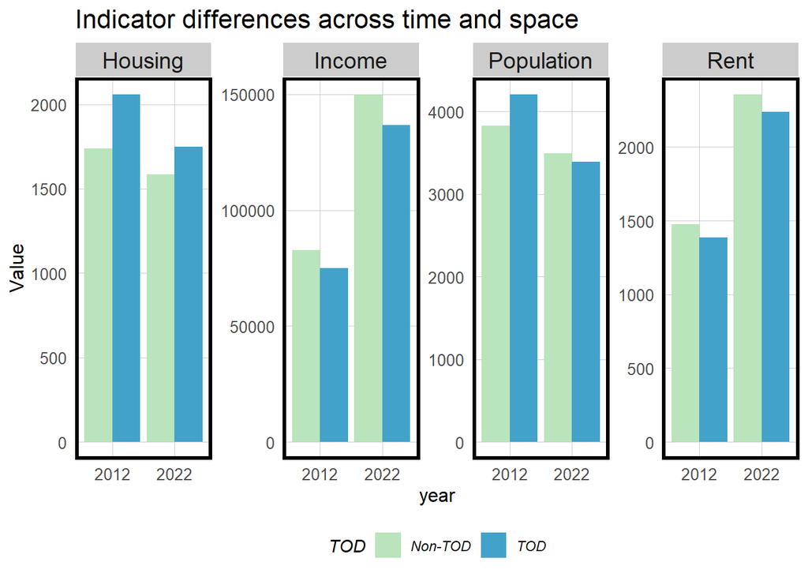

```r
allTracts.Summary %>%
  gather(Variable, Value, -year, -TOD) %>%
  ggplot(aes(year, Value, fill = TOD)) +
  geom_bar(stat = "identity", position = "dodge") +
  facet_wrap(~Variable, scales = "free", ncol=5) +
  scale_fill_manual(values = c("#bae4bc", "#43a2ca")) +
  labs(title = "Indicator differences across time and space") +
  plotTheme() +
  theme(legend.position="bottom")
```

## An increased willingness to pay for TOD among higher-income households

```r
allTracts.Diff <- allTracts.Summary %>%
  pivot_wider(names_from = TOD, values_from = c(Rent, Population, Income, Housing))
allTracts.Diff <- allTracts.Diff %>%
  mutate(Diff_Rent = 100*(Rent_TOD - `Rent_Non-TOD`)/`Rent_Non-TOD`,
         Diff_Population = 100*(Population_TOD - `Population_Non-TOD`)/`Population_Non-TOD`,
         Diff_Income = 100*(Income_TOD - `Income_Non-TOD`)/`Income_Non-TOD`,
         Diff_Housing = 100*(Housing_TOD - `Housing_Non-TOD`)/`Housing_Non-TOD`)%>%
  select(year, starts_with("Diff_"))

allTracts.Diff <- allTracts.Diff %>%
  rename(Rent = Diff_Rent,
         Population = Diff_Population,
         Income = Diff_Income,
         Housing = Diff_Housing)

allTracts.Summary.Diff <- bind_rows(
  allTracts.Summary,
  allTracts.Diff %>%
    mutate(TOD = "Difference(%)"))

allTracts.Summary.Diff %>%
  unite(year.TOD, year, TOD, sep = ": ", remove = T) %>%
  gather(Variable, Value, -year.TOD) %>%
  mutate(Value = round(Value, 2)) %>%
  spread(year.TOD, Value) %>%
  kable(caption = "A TOD indicator table across time and space") %>%
  kable_styling()
```

A TOD indicator table across time and space

| Variable | 2012: Difference(%) | 2012: Non-TOD | 2012: TOD | 2022: Difference(%) | 2022: Non-TOD | 2022: TOD |
| --- | --- | --- | --- | --- | --- | --- |
| Housing | 18.54 | 1737.00 | 2059.00 | 10.41 | 1585.00 | 1750.00 |
| Income | -9.43 | 82679.61 | 74879.22 | -8.77 | 149959.15 | 136801.04 |
| Population | 9.99 | 3824.00 | 4206.00 | -2.89 | 3491.00 | 3390.00 |
| Rent | -6.06 | 1475.11 | 1385.78 | -4.96 | 2356.36 | 2239.48 |

## Lower rent provides an opportunity for developers to get into the field

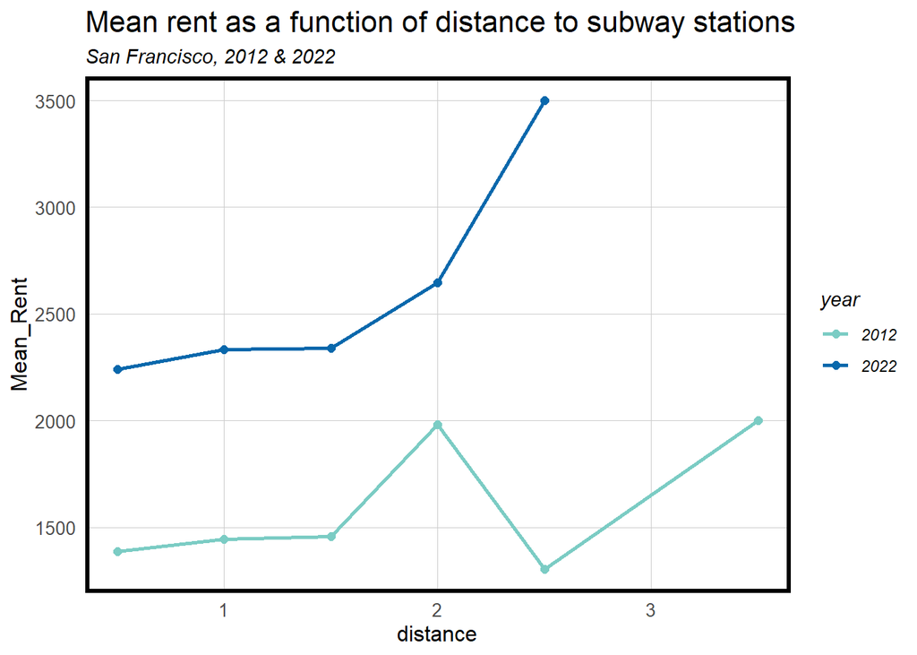

```r
# plot
ggplot(tracts.rings.summary,
       aes(distance, Mean_Rent, colour=year)) +
      geom_point(size=2) +
  geom_line(size=1) +
  scale_color_manual(values = c("#7bccc4", "#0868ac"))+
  labs(title = "Mean rent as a function of distance to subway stations",
       subtitle = "San Francisco, 2012 & 2022") +
  plotTheme()
```

Guided by the big rent theory, the line graph illustrates how rent and housing demand change with increasing distance from rail stations. There is a significant difference that the rent beyond two miles far from railway stations declined in 2012 while the rent grew faster in 2022. The result suggests an increasing popularity of the residential districts far from railway stations, which means a higher difficulty for developers to join the market of this field. However, the low level of the rent in TOD areas offers a good investment opportunity with the increasing demand from young and higher-income households.

Though TOD serves as a good option for developing single households, some areas work better for tourist infrastructures instead of houses.